# pset_iv_mk2215

### Q5

#### Present a graphical analysis to plot the first stage and reduced form results. How does this graphical analysis motivate the instrumental variables strategy?

```r
# bring the xtile command from the statar package
# create twenty percentile bins of distance
df$compulsoryS_bin <- xtile(df$compulsoryS, 20)
```

[figure not shown]

```r
# Preparing data for the first stage graph
first_stage <- df %>%
  group_by(compulsoryS_bin) %>%
  summarise(avg_school = mean(S), avg_comp = mean(compulsoryS_bin))

#Graphing the First stage plot
ggplot(data = first_stage, aes(x = avg_comp, y = avg_school)) +
  theme_bw()+
  geom_point(color = "darkblue")+
  labs(
    title = "The Positive Correlation between Compulsory Education and the Schooling",
    subtitle = "The first stage graph, aggregated in 5% percentile bin level",
    x = "Years of Compulsory Schooling in the Individual’s State",
    y = "Average Year of Schooling"
  )+
  ylim(min(first_stage$avg_school)-0.01,max(first_stage$avg_school)+0.01)
```

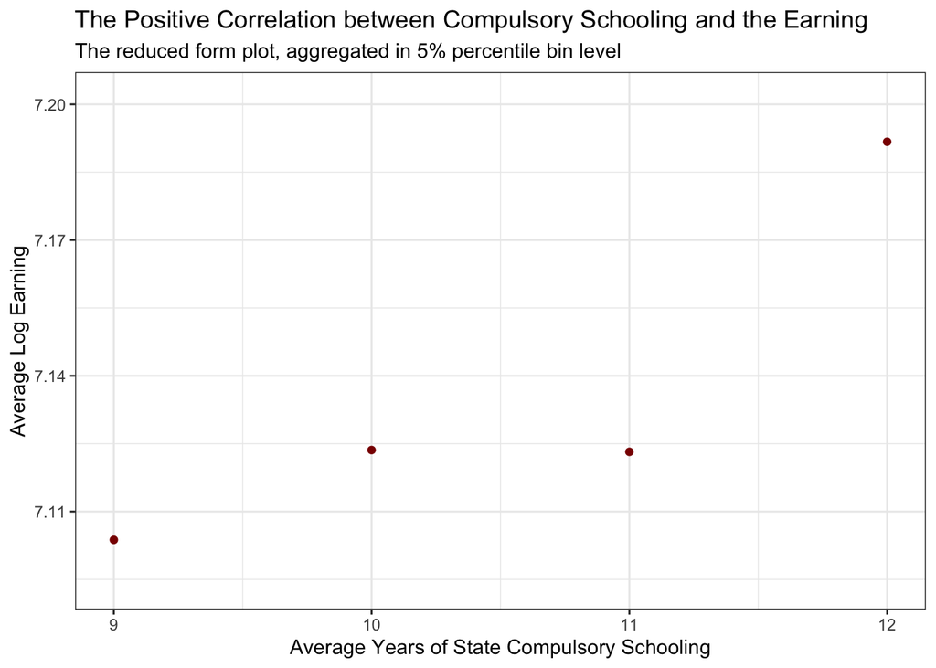

```r
# Preparing data for the reduced form plot
rd_form_plot <- df %>%
  group_by(compulsoryS_bin) %>%
  summarise(avg_earning = mean(lnearn), avg_dist = mean(compulsoryS))

# Graphing the Reduced Form Plot
ggplot(data = rd_form_plot, aes(x = avg_dist, y = avg_earning)) +
  theme_bw()+
  geom_point(color = "darkred")+
  labs(
    title = "The Positive Correlation between Compulsory Schooling and the Earning",
    subtitle = "The reduced form plot, aggregated in 5% percentile bin level",
    x = "Average Years of State Compulsory Schooling",
    y = "Average Log Earning"
  )+
  ylim(min(rd_form_plot$avg_earning)-0.01,max(rd_form_plot$avg_earning)+0.01)
```

From the first stage plot, we can observe a positive correlation between the year of state compulsory schooling and the average year of schooling. Thus, we can find out that the potential instrument(year of compulsory schooling) variable and the variable of interest(year of schooling) have a correlation, one of the two necessary assumption to apply the instrument variable. If the instrumental variable and variable of interest has positive correlation, then the instrumental variable (compulsory schooling) and the dependent variable (log earning) should have similar relationship between the variable of interest (year of schooling) and the dependent variable (log earning). Our Reduced Form Plot does show a positive correlation between the compulsory schooling and log earning, which aligns to the result of Q2 that the year of schooling and the log earning is positively correlated. Thus, we can apply compulsory schooling as an instrumental variable for this analysis

### Q6

#### Estimate the first stage regression. Is compulsory schooling a statistically significant predictor of schooling?

```r
# First stage regression
first_stage_reg <- lm(S ~ compulsoryS + xpr + xpr2 + female, data = df)

summary(first_stage_reg)
```

```
##
## Call:
## lm(formula = S ~ compulsoryS + xpr + xpr2 + female, data = df)
##
## Residuals:
##     Min      1Q  Median      3Q     Max
## -5.6646 -2.2188 -0.2249  2.3339  5.0136
##
## Coefficients:
##               Estimate Std. Error t value Pr(>|t|)
## (Intercept)  1.102e+01  9.194e-02 119.892   <2e-16 ***
## compulsoryS  2.204e-01  8.365e-03  26.343   <2e-16 ***
## xpr         -1.557e-03  3.441e-03  -0.453    0.651
## xpr2         3.989e-05  9.287e-05   0.429    0.668
## female      -4.983e-03  1.603e-02  -0.311    0.756
## ---
## Signif. codes:  0 '***' 0.001 '**' 0.01 '*' 0.05 '.' 0.1 ' ' 1
##
## Residual standard error: 2.535 on 99995 degrees of freedom
## Multiple R-squared:  0.006894,   Adjusted R-squared:  0.006854
## F-statistic: 173.5 on 4 and 99995 DF,  p-value: < 2.2e-16
```

Yes, from the t value and the p value of the regression, we learn that the compulsory schooling has a statistically significant positive correlation with the years of schooling

### Q7

#### Use ivreg to implement the IV estimator in which we instrument for schooling using compulsory schooling. What are your results? How does the IV estimate for the return to schooling compare to the OLS estimate?

```r
# Run a regression while implementing an instrumental variable
iv_reg <- ivreg(lnearn ~ female + xpr+ xpr2 |S| compulsoryS, data = df)

summary(iv_reg)
```

```
##
## Call:
## ivreg(formula = lnearn ~ female + xpr + xpr2 | S | compulsoryS,
##     data = df)
##
## Residuals:
##       Min        1Q    Median        3Q       Max
## -5.155304 -0.816166 -0.001561  0.819575  5.728230
##
## Coefficients:
##               Estimate Std. Error  t value Pr(>|t|)
## (Intercept)  6.777e+00  2.414e-01   28.077   <2e-16 ***
## S            1.623e-01  1.808e-02    8.976   <2e-16 ***
## female       1.322e+00  7.638e-03  173.025   <2e-16 ***
## xpr          4.904e-02  1.639e-03   29.920   <2e-16 ***
## xpr2        -7.962e-03  4.423e-05 -179.996   <2e-16 ***
##
## Diagnostic tests:
##                    df1   df2 statistic p-value
## Weak instruments     1 99995   693.968  <2e-16 ***
## Wu-Hausman           1 99994     0.365   0.546
## Sargan               0    NA        NA      NA
## ---
## Signif. codes:  0 '***' 0.001 '**' 0.01 '*' 0.05 '.' 0.1 ' ' 1
##
## Residual standard error: 1.208 on 99995 degrees of freedom
## Multiple R-Squared: 0.8169,  Adjusted R-squared: 0.8169
## Wald test: 1.09e+05 on 4 and 99995 DF,  p-value: < 2.2e-16
```

```r
print(paste("The coefficient of S without instrumental variable: ", summary(basic_reg)$coefficients[3,1]))
```

```
## [1] "The coefficient of S without instrumental variable:  0.151394554921255"
```

```r
print(paste("The coefficient of S with instrumental variable: ", summary(iv_reg)$coefficients[2,1]))
```

```
## [1] "The coefficient of S with instrumental variable:  0.162282905436372"
```

The fixed effect regression applying compulsory schooling as an instrumental variable shows that the positive correlation between the year of schooling and log earning is statistically significant. Originally, we expected an upward bias because we expect that the year of schooling incorporate factors other than the pure effect of the year of schooling. However, the coefficient with the instrument actually increases. This result may be due to the “Local Average Treatment Affect” since we are using the estimated year of schooling based on the year of compulsory schooling instead of the original data on the year of schooling.

### Q8

#### Suppose that we think the return to schooling varies by gender and we want to instrument for the female*S interaction term using compulsory schooling interacted with gender. Estimate the first stage regressions (note that we have 2 variables that need to be instrumented). Do we have a valid instrument for each variable that needs to be instrumented?

```r
# First Stage for female*S
df_interact <- df %>%
  mutate(
    female_s = female * S
  )

first_stage_int <- lm(female_s ~ compulsoryS*female + xpr + xpr2, data = df_interact)
summary(first_stage_int)
```

```
##
## Call:
## lm(formula = female_s ~ compulsoryS * female + xpr + xpr2, data = df_interact)
##
## Residuals:
##     Min      1Q  Median      3Q     Max
## -5.6567 -0.4308  0.0002  0.0012  5.0135
##
## Coefficients:
##                      Estimate Std. Error t value Pr(>|t|)
## (Intercept)         2.669e-03  9.011e-02   0.030    0.976
## compulsoryS         1.253e-05  8.384e-03   0.001    0.999
## female              1.099e+01  1.248e-01  88.066   <2e-16 ***
## xpr                -2.405e-04  2.435e-03  -0.099    0.921
## xpr2                3.621e-06  6.572e-05   0.055    0.956
## compulsoryS:female  2.222e-01  1.184e-02  18.767   <2e-16 ***
## ---
## Signif. codes:  0 '***' 0.001 '**' 0.01 '*' 0.05 '.' 0.1 ' ' 1
##
## Residual standard error: 1.794 on 99994 degrees of freedom
## Multiple R-squared:  0.9324, Adjusted R-squared:  0.9324
## F-statistic: 2.757e+05 on 5 and 99994 DF,  p-value: < 2.2e-16
```

### Q9

#### Estimate the IV results related to the first stage regressions in (8). Can we reject the hypothesis that the IV estimate of the coefficient on female*S is 0? What are the conclusions about whether the return to schooling varies based on gender or not?

```r
ivreg_int <- ivreg(lnearn ~ xpr+ xpr2 |female_s| female*compulsoryS, data = df_interact)
summary(ivreg_int)
```

```
##
## Call:
## ivreg(formula = lnearn ~ xpr + xpr2 | female_s | female * compulsoryS,
##     data = df_interact)
##
## Residuals:
##       Min        1Q    Median        3Q       Max
## -5.050179 -0.832817  0.001635  0.835313  5.834370
##
## Coefficients:
##               Estimate Std. Error t value Pr(>|t|)
## (Intercept)  8.9404881  0.0135968  657.54   <2e-16 ***
## female_s     0.0991921  0.0005832  170.09   <2e-16 ***
## xpr          0.0489016  0.0016675   29.33   <2e-16 ***
## xpr2        -0.0079579  0.0000450 -176.85   <2e-16 ***
##
## Diagnostic tests:
##                    df1   df2 statistic  p-value
## Weak instruments     3 99994 459520.65  < 2e-16 ***
## Wu-Hausman           1 99995   2064.16  < 2e-16 ***
## Sargan               2    NA     39.05 3.32e-09 ***
## ---
## Signif. codes:  0 '***' 0.001 '**' 0.01 '*' 0.05 '.' 0.1 ' ' 1
##
## Residual standard error: 1.228 on 99996 degrees of freedom
## Multiple R-Squared: 0.8105,  Adjusted R-squared: 0.8105
## Wald test: 1.404e+05 on 3 and 99996 DF,  p-value: < 2.2e-16
```